# Solid fuels model — monthly BVAR-SV-outlier

```
Recursive identification
Reference date: 2026-06-01
HD maximum reconstruction error: 5.68 × 10⁻¹⁴
```

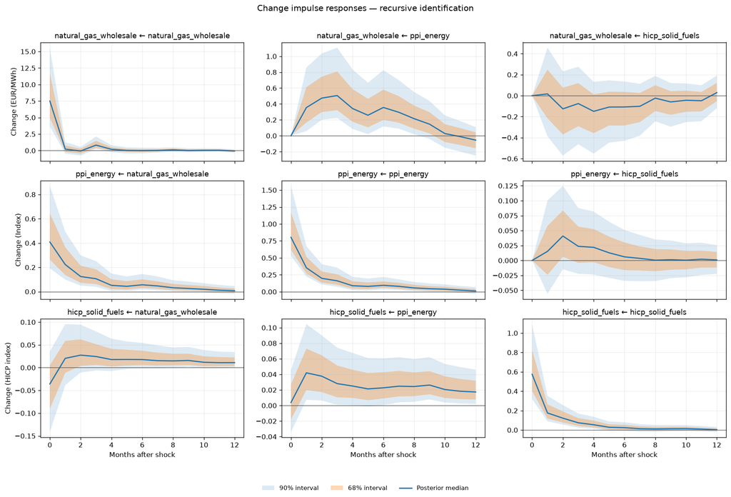

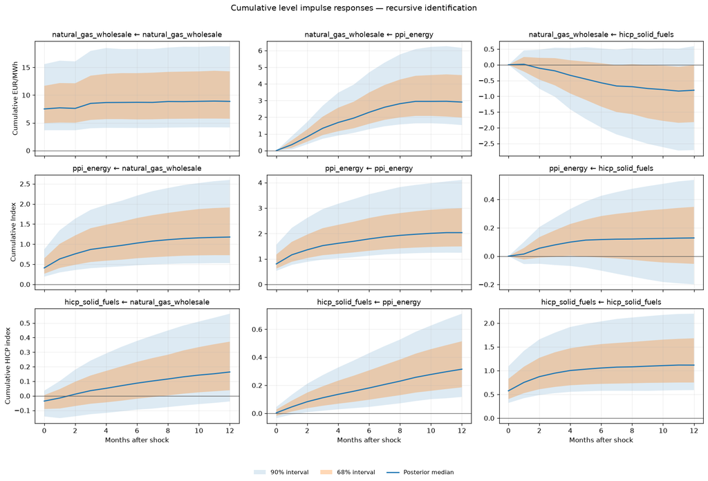

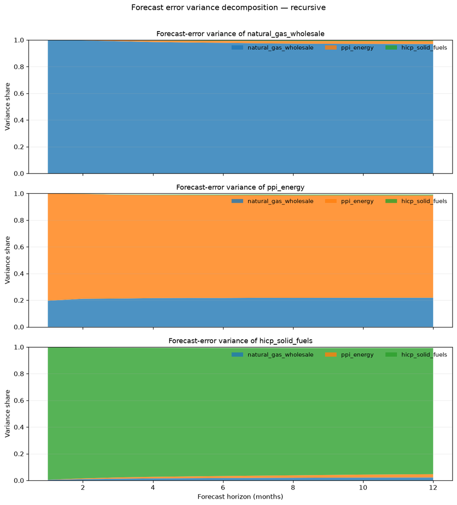

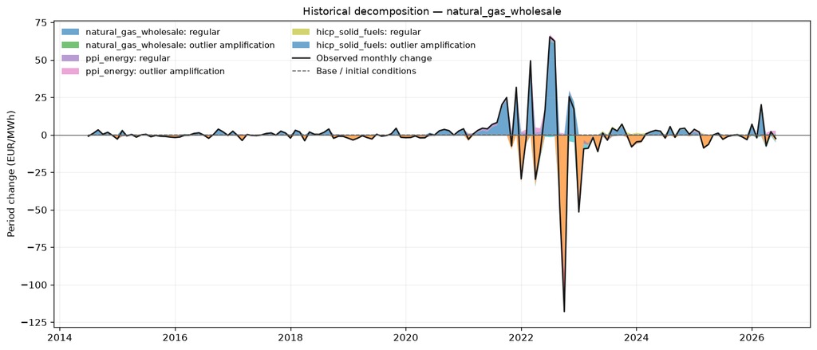

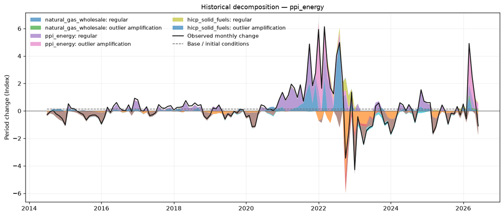

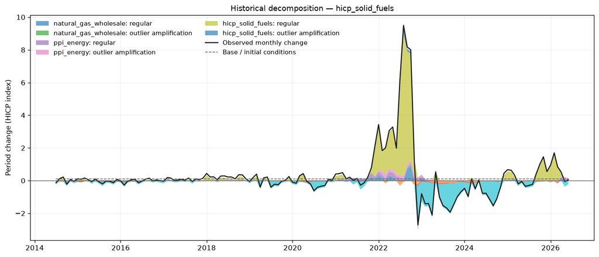

```
Sign-restricted identification
Accepted posterior-draw share: 100.00%
Mean attempts per accepted draw: 5.36
HD maximum reconstruction error: 1.85 × 10⁻¹³
```

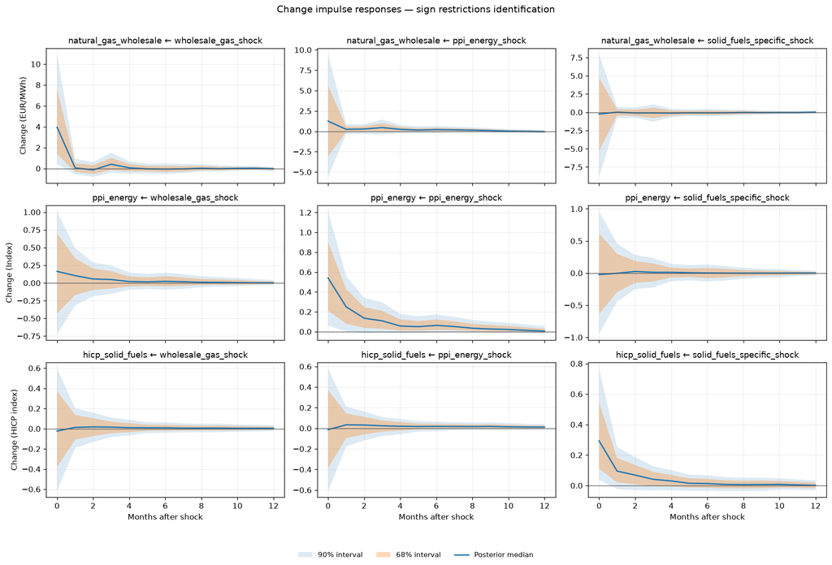

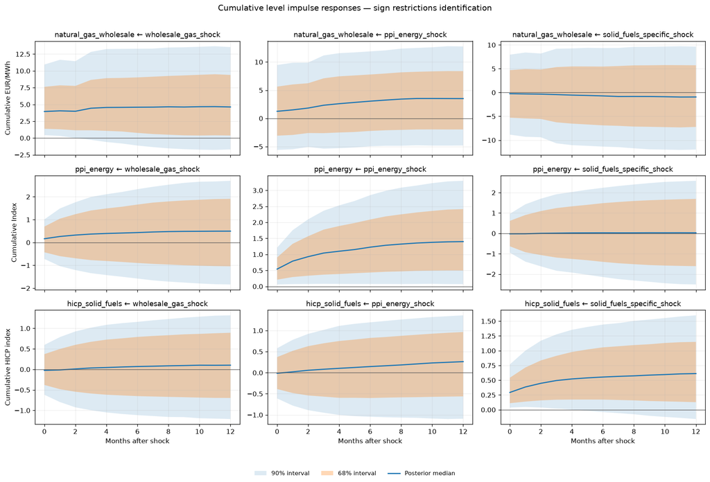

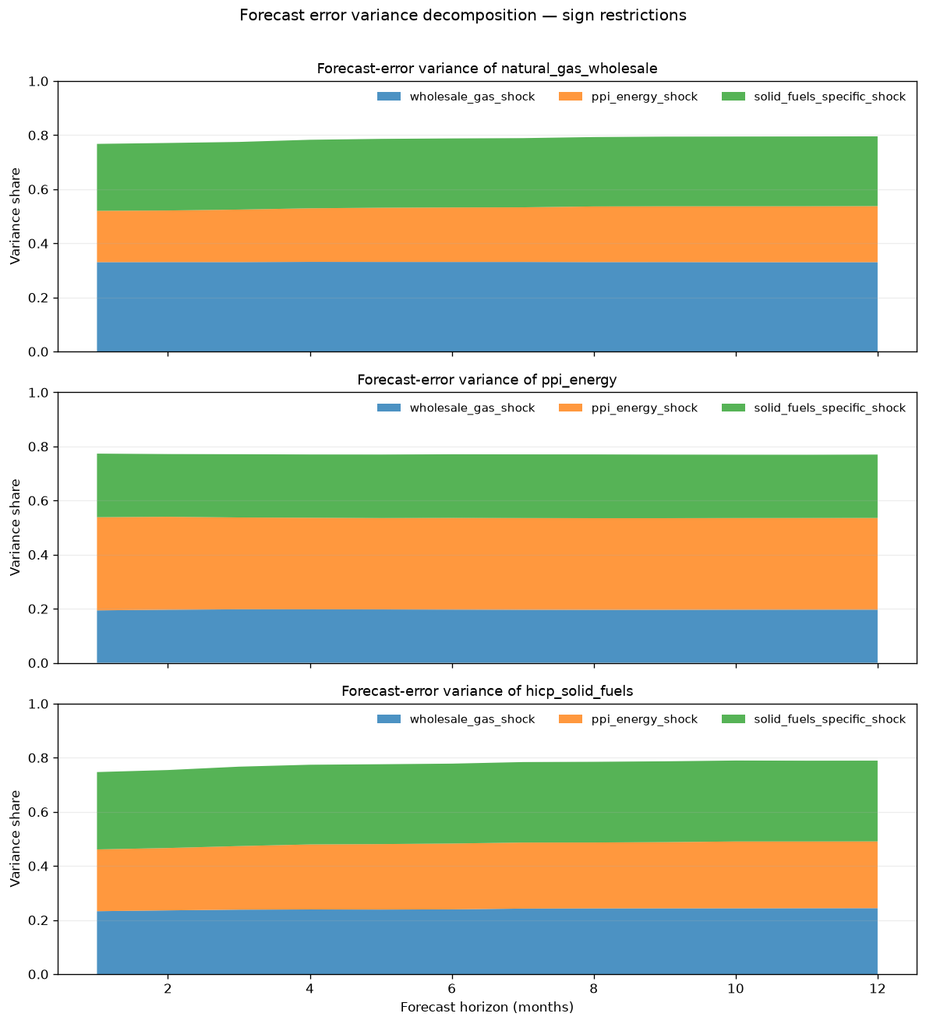

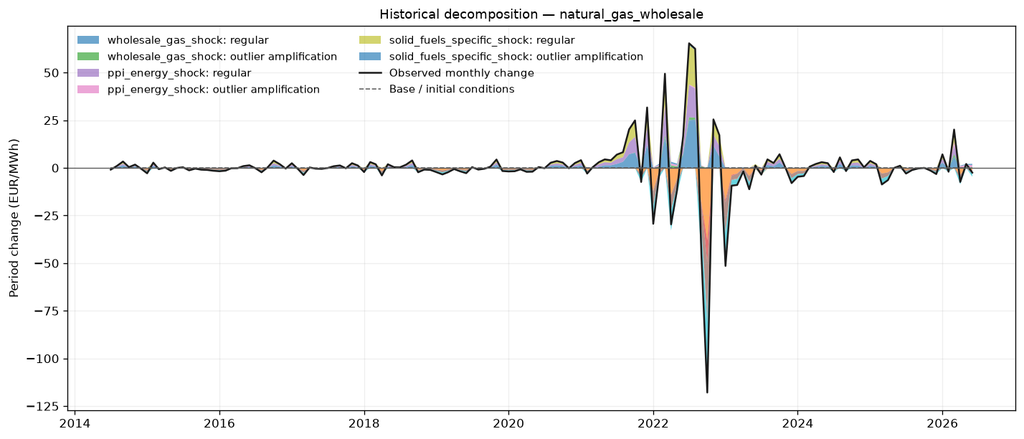

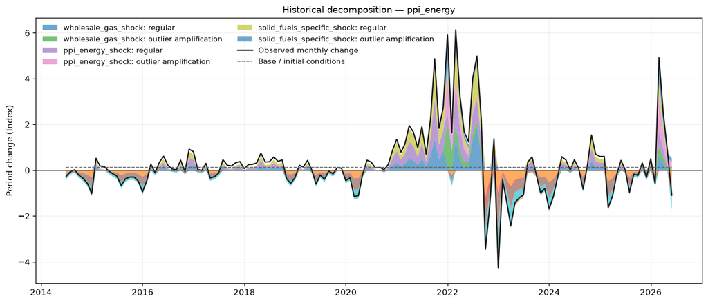

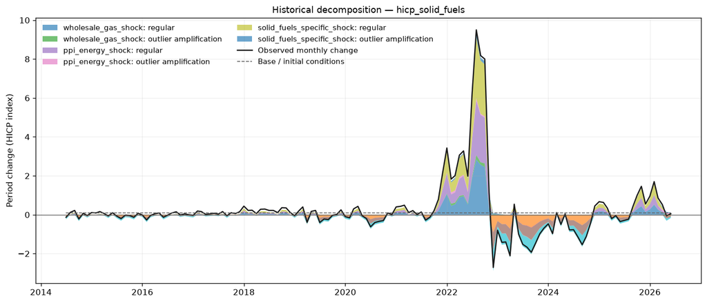

```python
COMPONENT_SIGN_RESTRICTIONS = {
    "wholesale_gas_shock": {
        "natural_gas_wholesale": {0: +1},
    },
    "ppi_energy_shock": {
        "ppi_energy": {0: +1},
    },
    "solid_fuels_specific_shock": {
        TARGET: {0: +1},
    },
}

STRUCTURAL_REFERENCE_DATE = prep["balanced_end"]
STRUCTURAL_HORIZON = 12

irf_recursive = impulse_responses(
    result,
    identification="recursive",
    reference_date=STRUCTURAL_REFERENCE_DATE,
    horizon=STRUCTURAL_HORIZON,
    shock_unit="structural_std",
    include_outlier_scale=False,
)
fevd_recursive = forecast_error_variance_decomposition(
    result,
    identification="recursive",
    reference_date=STRUCTURAL_REFERENCE_DATE,
    horizon=STRUCTURAL_HORIZON,
    include_outlier_scale=False,
)
hd_recursive = historical_decomposition(
    result,
    identification="recursive",
    reference_date=STRUCTURAL_REFERENCE_DATE,
    split_outlier_amplification=True,
)

print("Recursive identification")
print(f"Reference date: {pd.Timestamp(STRUCTURAL_REFERENCE_DATE).date()}")
print(f"HD maximum reconstruction error: {format_number(hd_recursive['max_reconstruction_error'])}")
plot_impulse_responses(irf_recursive, cumulative=False, units=UNITS)
plot_impulse_responses(irf_recursive, cumulative=True, units=UNITS)
plot_fevd(fevd_recursive)
for response in VARIABLES:
    plot_historical_decomposition(
        hd_recursive,
        response=response,
        last_obs=144,
        unit=UNITS[response],
    )
plt.show()

irf_sign = impulse_responses(
    result,
    identification="sign",
    reference_date=STRUCTURAL_REFERENCE_DATE,
    sign_restrictions=COMPONENT_SIGN_RESTRICTIONS,
    horizon=STRUCTURAL_HORIZON,
    shock_unit="structural_std",
    include_outlier_scale=False,
    max_tries=20_000,
    seed=SEED,
)
fevd_sign = forecast_error_variance_decomposition(
    result,
    identification="sign",
    reference_date=STRUCTURAL_REFERENCE_DATE,
    sign_restrictions=COMPONENT_SIGN_RESTRICTIONS,
    horizon=STRUCTURAL_HORIZON,
    include_outlier_scale=False,
    max_tries=20_000,
    seed=SEED,
)
hd_sign = historical_decomposition(
    result,
    identification="sign",
    reference_date=STRUCTURAL_REFERENCE_DATE,
    sign_restrictions=COMPONENT_SIGN_RESTRICTIONS,
    split_outlier_amplification=True,
    max_tries=20_000,
    seed=SEED,
)

print()
print("Sign-restricted identification")
print(f"Accepted posterior-draw share: {irf_sign['acceptance_rate']:.2%}")
print(f"Mean attempts per accepted draw: {irf_sign['mean_attempts_per_accepted_draw']:.2f}")
print(f"HD maximum reconstruction error: {format_number(hd_sign['max_reconstruction_error'])}")
plot_impulse_responses(irf_sign, cumulative=False, units=UNITS)
plot_impulse_responses(irf_sign, cumulative=True, units=UNITS)
plot_fevd(fevd_sign)
for response in VARIABLES:
    plot_historical_decomposition(
        hd_sign,
        response=response,
        last_obs=144,
        unit=UNITS[response],
    )
plt.show()
```

## 10. Diagnosis

### 10.1 Stationarity of transformed endogenous data

```python
stationarity_table = stationarity_tests(prep["balanced"])
display(style_numeric_table(
    stationarity_table,
    caption="Stationarity diagnostics",
))
```

Stationarity diagnostics

| variable | ADF statistic | ADF p-value | ADF lags | KPSS statistic | KPSS p-value | KPSS lags | observations |
| --- | --- | --- | --- | --- | --- | --- | --- |
| natural_gas_wholesale | -5.10 | 1.41 × 10⁻⁵ | 15.00 | 0.04 | 0.10 | 26.00 | 301.00 |
| ppi_energy | -4.48 | 2.15 × 10⁻⁴ | 17.00 | 0.11 | 0.10 | 9.00 | 299.00 |
| hicp_solid_fuels | -4.37 | 3.40 × 10⁻⁴ | 15.00 | 0.09 | 0.10 | 9.00 | 301.00 |

### 10.2 MCMC effective sample size and autocorrelation

MCMC diagnostics

|  | posterior_mean | posterior_sd | ESS | MCSE_mean | MCSE_over_sd |
| --- | --- | --- | --- | --- | --- |
| phi[ppi_energy] | 0.04 | 0.02 | 32.45 | 3.10 × 10⁻³ | 0.18 |
| phi[hicp_solid_fuels] | 0.13 | 0.05 | 71.33 | 5.99 × 10⁻³ | 0.12 |
| phi[natural_gas_wholesale] | 0.17 | 0.05 | 85.06 | 5.64 × 10⁻³ | 0.11 |
| A[ppi_energy,natural_gas_wholesale] | -0.05 | 7.42 × 10⁻³ | 183.11 | 5.48 × 10⁻⁴ | 0.07 |
| log likelihood | -647.26 | 13.92 | 204.04 | 0.97 | 0.07 |
| p_outlier[natural_gas_wholesale] | 0.01 | 7.14 × 10⁻³ | 424.90 | 3.46 × 10⁻⁴ | 0.05 |
| p_outlier[ppi_energy] | 0.02 | 7.83 × 10⁻³ | 514.55 | 3.45 × 10⁻⁴ | 0.04 |
| p_outlier[hicp_solid_fuels] | 0.01 | 6.40 × 10⁻³ | 629.65 | 2.55 × 10⁻⁴ | 0.04 |
| own L1[natural_gas_wholesale] | 5.56 × 10⁻³ | 0.06 | 728.90 | 2.18 × 10⁻³ | 0.04 |
| own L1[hicp_solid_fuels] | 0.31 | 0.06 | 830.24 | 2.16 × 10⁻³ | 0.03 |
| own L1[ppi_energy] | 0.44 | 0.05 | 1821.18 | 1.22 × 10⁻³ | 0.02 |
| spectral radius | 0.83 | 0.03 | 2474.87 | 5.68 × 10⁻⁴ | 0.02 |

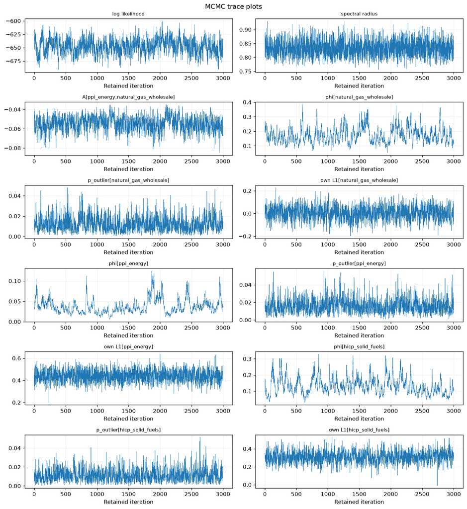

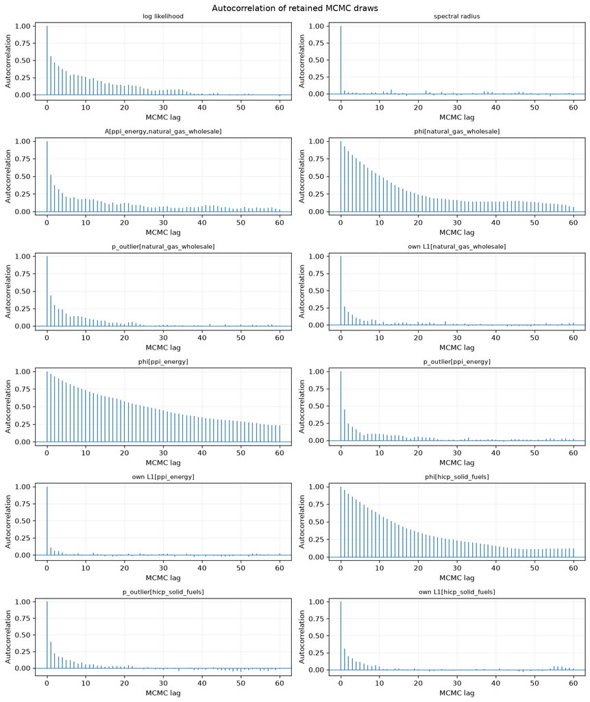

```python
diagnostic_table = mcmc_diagnostics(result)
display(style_numeric_table(
    diagnostic_table.sort_values("ESS"),
    caption="MCMC diagnostics",
))
plot_trace_grid(result)
plot_chain_acf_grid(result, nlags=60)
plt.show()
```

### 10.3 Stability

VAR stability diagnostics

|  | value |
| --- | --- |
| retained_draws | 3000.00 |
| median_spectral_radius | 0.83 |
| q95_spectral_radius | 0.88 |
| maximum_spectral_radius | 0.93 |
| retained_unstable_share | 0.00 |
| B_total_proposals | 6000.00 |
| B_unstable_proposals | 0.00 |
| B_instability_rejection_rate | 0.00 |

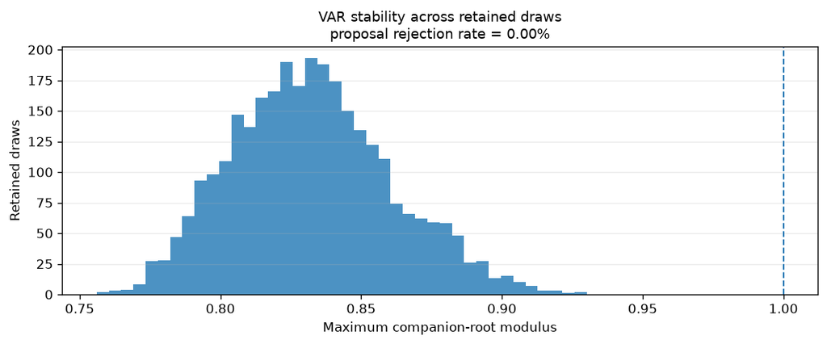

```python
display(style_numeric_table(
    stability_diagnostics(result).to_frame("value"),
    caption="VAR stability diagnostics",
))
plot_spectral_radius(result)
plt.show()
```

### 10.4 Posterior predictive checks

Posterior predictive checks — natural_gas_wholesale

|  | observed | replicated_median | replicated_q05 | replicated_q95 |
| --- | --- | --- | --- | --- |
| natural_gas_wholesale: mean | 0.10 | 0.01 | -1.03 | 1.50 |
| natural_gas_wholesale: sd | 10.95 | 9.27 | 6.39 | 22.02 |
| natural_gas_wholesale: maximum_absolute | 117.89 | 83.36 | 46.89 | 364.19 |

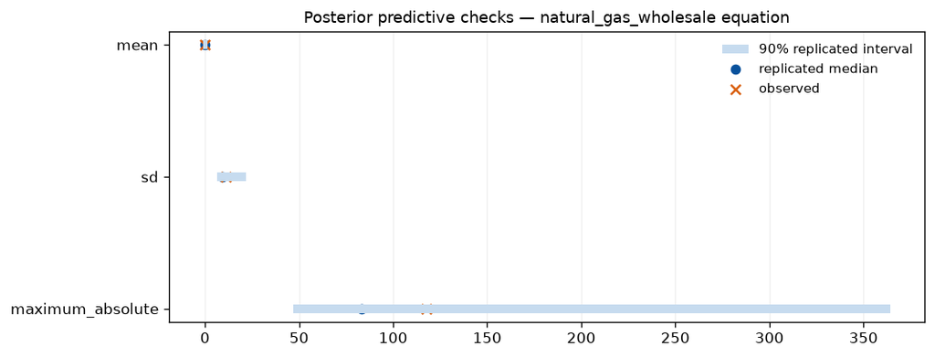

Posterior predictive checks — ppi_energy

|  | observed | replicated_median | replicated_q05 | replicated_q95 |
| --- | --- | --- | --- | --- |
| ppi_energy: mean | 0.20 | 0.13 | -0.15 | 0.42 |
| ppi_energy: sd | 1.02 | 1.18 | 0.77 | 2.35 |
| ppi_energy: maximum_absolute | 6.13 | 10.62 | 4.92 | 29.38 |

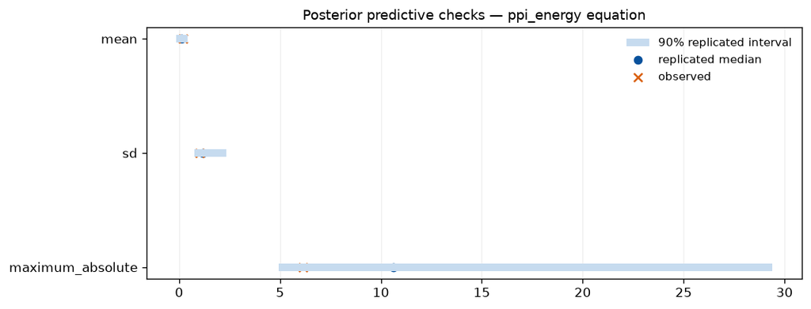

Posterior predictive checks — hicp_solid_fuels

|  | observed | replicated_median | replicated_q05 | replicated_q95 |
| --- | --- | --- | --- | --- |
| hicp_solid_fuels: mean | 0.19 | 0.11 | -0.06 | 0.28 |
| hicp_solid_fuels: sd | 1.08 | 0.74 | 0.50 | 1.23 |
| hicp_solid_fuels: maximum_absolute | 9.50 | 6.15 | 3.11 | 14.77 |

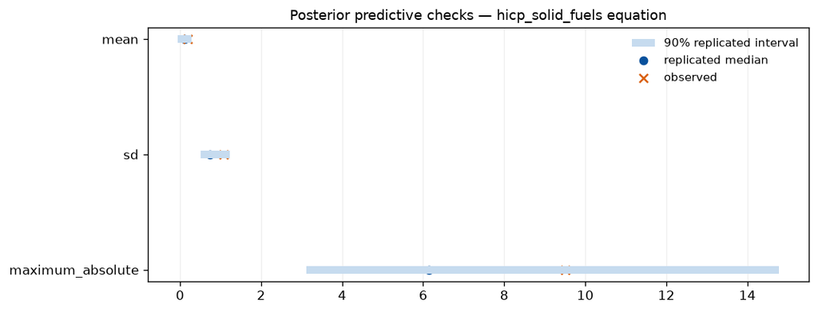

```python
ppc_summary, ppc_draws = posterior_predictive_statistics(
    result,
    n_draws=min(300, result["n_draws"]),
    seed=2027,
)
for equation in VARIABLES:
    equation_rows = ppc_summary.loc[
        [str(index).startswith(f"{equation}:") for index in ppc_summary.index]
    ]
    display(style_numeric_table(
        equation_rows,
        caption=f"Posterior predictive checks — {equation}",
    ))
    plot_posterior_predictive_check(ppc_summary, equation=equation)
    plt.show()
```

## 11. Validation checklist

Before freezing the solid fuels model, verify:

- the endogenous order is `natural_gas_wholesale`, `ppi_energy`, `hicp_solid_fuels`;
- the balanced sample has no interior missing month after absolute differencing;
- both conditional paths satisfy their imposed levels within numerical precision;
- the historical decomposition reconstructs observed changes within numerical precision;
- the HICP level paths and year-on-year paths are aligned to the same forecast dates;
- the Run ID and saved result directory are retained in the canonical HTML export.